# R Notebook

```r
library(tidyverse) #Para leer datos y para manipulacion de datos en general
```

La logica basica del test es que dos ratones se encuentran y hay 3 desenlaces posibles para uno de los dos ratones:

- Pierde
- Gana
- Empata (cuando ninguno de los dos se logra sacar del tubo en el tiempo que dura el test)

```r
dominancia_machos <- read_xlsx('Data/R_TD_M.xlsx')
dominancia_machos <- dominancia_machos %>% mutate(geno = factor(geno),
                                                  geno = fct_relevel(geno, 'WT','KO'))
```

# Preprocesamiento

No tenemos identificadores unicos para cada animal lo cual podemos comprobar facilmente chequeando la columna `id`

```r
length(unique(dominancia_machos$id)) - nrow(dominancia_machos)
```

```
[1] -7
```

La resta tendria que dar 0 pero justamente lo que ocurre es que tenemos mas filas que numeros de identificacion y siendo que cada fila corresponde a un raton tenemos numeros de identificacion repetidos. Vamos a generar unos nuevos numeros de identificacion dummy.

```r
dominancia_machos <- dominancia_machos %>% mutate(dummy_id = 1:n())
```

# Abordaje tradicional

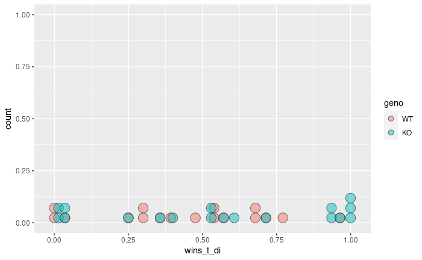

Para analizar estos resultados se suele emplear un modelo frecuentista clasico asi que vamos a representarlo con una regresion lineal simple.

```r
modelo_tradicional_simple <- lm(
  wins_t_di ~ geno,
  data = dominancia_machos
)
```

Primero vemos el resumen de resultados del modelo.

```r
summary(modelo_tradicional_simple)
```

```
Call:
lm(formula = wins_t_di ~ geno, data = dominancia_machos)

Residuals:
     Min       1Q   Median       3Q      Max
-0.54974 -0.19392  0.02169  0.25119  0.51905

Coefficients:
            Estimate Std. Error t value Pr(>|t|)
(Intercept)   0.4452     0.0802   5.551 3.62e-06 ***
genoKO        0.1045     0.1118   0.934    0.357
---
Signif. codes:  0 ‘***’ 0.001 ‘**’ 0.01 ‘*’ 0.05 ‘.’ 0.1 ‘ ’ 1

Residual standard error: 0.3307 on 33 degrees of freedom
Multiple R-squared:  0.02577,   Adjusted R-squared:  -0.003747
F-statistic: 0.8731 on 1 and 33 DF,  p-value: 0.3569
```

Despues graficamos la estimacion para los dos grupos que hace el modelo.

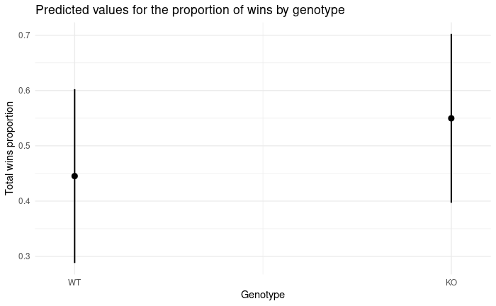

Por ultimo chequeamos algunos diagnosticos.

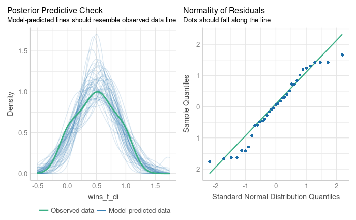

# Modelo beta

## Priors

```r
get_prior(wins_t_di ~ geno, data = beta_datos, family = Beta())
```

```
                prior     class   coef group resp dpar nlpar lb ub       source
               (flat)         b                                         default
               (flat)         b genoKO                             (vectorized)
 student_t(3, 0, 2.5) Intercept                                         default
    gamma(0.01, 0.01)       phi                               0         default
```

### Prior predictive check

```r
table(dominancia_machos$geno)
```

```
WT KO
17 18
```

```r
prior_predictive_fun()
```

```
 [1] 0.712567972 0.950579288 0.185525341 0.639492716 0.999996740 0.511259594 0.773367166 0.985755655 0.994995965 0.768713700
[11] 0.832448479 0.334912886 0.932670441 0.333483043 0.006946253 0.992184405 0.069063441 0.975661985 0.775176156 0.845924599
[21] 0.970405353 0.987274438 0.835294340 0.999330557 0.311247523 0.520991129 0.282515284 0.829573802 0.997318073 0.998236118
[31] 0.970198419 0.913653254 0.146467554 0.393317559 0.273779991
```

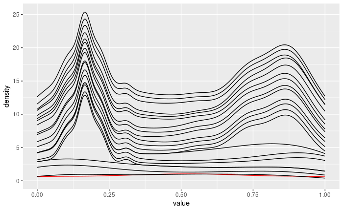

```r
beta_priors <- set_prior(
  'normal(0,2)', class = 'b',
  'normal(0,2)', class = 'Intercept'
)
```

```
Error in set_prior("normal(0,2)", class = "b", "normal(0,2)", class = "Intercept") :
  could not find function "set_prior"
```

# Modelo Binomial

Vamos a tomar un raton cualquiera para ejemplificar.

```r
raton_ejemplo <- sample(dominancia_machos$dummy_id, 1)
raton_ejemplo_data <- dominancia_machos %>% filter(dummy_id == raton_ejemplo)
head(raton_ejemplo_data)
```

Para hacer el calculo de la binomial necesitamos la cantidad de exitos (*k*) y la cantidad de intentos (*n*). Lo primero esta dentro de las columnas `d*_wins` donde el `*` depende del numero del dia del testeo. El `n` en cambio esta implicito en la jaula a la que pertenece el animal. Cada raton puede cruzarse con $N_{cage}-1$ ratones.

Entonces si este raton pertenece a la jaula 6 podemos calcular cuantos ratones tiene esa jaula y restando uno vamos a averiguar la cantidad de intentos `n` que nos interesa.

```r
dominancia_machos %>% count(cage) %>% filter(cage == 6) %>% pull(n)
```

Podemos entonces agregar este numero a nuestro dataset de ejemplo.

```r
raton_ejemplo_data <- raton_ejemplo_data %>% mutate(
  cant_intentos = dominancia_machos %>% count(cage) %>% filter(cage == 6) %>% pull(n) - 1
)
```

Con todo esto ya podemos computar lo que nos interesa. Para eso vamos a usar una distribucion conjugada Beta-Binomial. Como prior vamos a usar $Beta(2,2)$ asumiendo entonces que el raton tiene iguales chances de ganar que de perder. Ya tenemos todos los elementos para calcular la distribucion posterior.

```r
plot_beta_binomial(
    2, #Prior
    2, #Prior
    y = raton_ejemplo_data %>% pull(d1_wins),
    n = raton_ejemplo_data %>% pull(cant_intentos)
)
summarize_beta_binomial(
   2, #Prior
   2, #Prior
   y = raton_ejemplo_data %>% pull(d1_wins),
   n = raton_ejemplo_data %>% pull(cant_intentos)
)
```

[output not shown]

```r
pbeta(0.5, 2, 6)
```

Tenemos un 93% de chances de que la probabilidad de ganar de este raton este por debajo de 50%.

Tambien podemos calcular como se informo nuestro intervalo del 95% comparando la distribucion prior con la posterior.

```r
qbeta(c(0.025,0.975), 2, 2)
qbeta(c(0.025,0.975), 2, 6)
```

Ahora bien. Si asumimos que el parametro que gobierna el proceso binomial en este raton fue constante a lo largo de los dias podemos combinar toda esa informacion en lugar de usar los datos de un solo dia como hicimos recien.

Para esto el procedimiento va a ser muy similar. Mantenemos el mismo prior pero ahora vamos a sumar todas las victorias que consiguio al sumar sobre todas las columnas que sean `d*_wins`. Para calcular la cantidad de intentos simplemente multiplicamos el `n` que usamos antes por la cantidad de columnas `d*_wins`.

```r
plot_beta_binomial(
    2, #Prior
    2, #Prior
    y = raton_ejemplo_data %>% summarise(suma = rowSums(across(matches('d\\d_wins')))) %>% pull(suma),
    n = raton_ejemplo_data %>% pull(cant_intentos) * (raton_ejemplo_data %>% select(matches('d\\d_wins')) |> ncol())
)
summarize_beta_binomial(
  2, #Prior
    2, #Prior
    y = raton_ejemplo_data %>% summarise(suma = rowSums(across(matches('d\\d_wins')))) %>% pull(suma),
    n = raton_ejemplo_data %>% pull(cant_intentos) * (raton_ejemplo_data %>% select(matches('d\\d_wins')) |> ncol())
)
```

Nuestro modelo tiene muchisima menos incerteza ahora.

```r
pbeta(0.5, 13, 19)
qbeta(c(0.025,0.975), 13, 19)
```

Nuestra intuicion cambio y ahora hay nada mas un 85% de chances de que este raton tiene una probabilidad de ganar menor al 50%. Tambien podemos calcular un intervalo de credibilidad del 95% sobre la probabilidad de ganar que esta entre 24% y 57%.

En principio podemos repetir esta misma logica para cada uno de los ratones en nuestros datos.

```r
beta_individual <- dominancia_machos %>% group_by(cage) %>% mutate(cant_intentos = n() - 1) %>% group_by(dummy_id) %>%
  summarise(
    suma = rowSums(across(matches('d\\d_wins'))),
    n = cant_intentos*dominancia_machos %>% select(matches('d\\d_wins')) |> ncol(),
    geno = geno
  )

head(beta_individual)
```

```r
beta_individual <- beta_individual %>%
  mutate(
    posterior_alfa = 2 + suma,
    posterior_beta = 2 + n-suma
  )

head(beta_individual)
```

```r
pmap(beta_individual,
     ~ data.frame(
       raton = ..1,
       geno = ..4,
       parametro = seq(0,1,0.01),
       densidad_posterior = dbeta(
       seq(0,1,0.01),..5, ..6
       )
     )
) %>% bind_rows() %>%
  ggplot(
    aes(x = parametro, y = densidad_posterior, color = geno, group = raton)
  ) +
  geom_line()
```

[output not shown]

Significa que para cada raton tenemos una distribucion de probabilidad de la probabilidad de ganar un encuentro cualquiera. Podemos calcular la media, moda y mediana de estas distribuciones posteriores.

```r
beta_individual <- beta_individual %>%
  mutate(
    media = posterior_alfa/(posterior_alfa + posterior_beta),
    mediana = qbeta(0.5, posterior_alfa, posterior_beta),
    moda = (posterior_alfa - 1)/(posterior_alfa+posterior_beta - 2)
  )

head(beta_individual)
```

Ahora podria comparar este numero con el que calculo de manera “frecuentista”.

```r
combined_measures <- beta_individual %>% pivot_longer(cols = c(media,mediana,moda), names_to = 'medida', values_to = 'valor') %>%
right_join(
  dominancia_machos %>% select(dummy_id, wins_t_di),
  by = 'dummy_id'
)

combined_measures %>%
  ggplot(
    aes(x = valor, y = wins_t_di, color = medida)
  ) +
  geom_point(size = 2) +
  geom_abline(slope = 1, intercept = 0) +
  facet_wrap(~medida, nrow = 3)
```

[output not shown]

```r
combined_measures %>% mutate(diferencia = wins_t_di - valor) %>%
  ggplot(
    aes(x = wins_t_di, y = diferencia)
  ) +
  geom_jitter(aes(color = diferencia)) +
  geom_hline(yintercept = 0) +
  scale_color_gradient2(low = 'blue', mid = 'grey', high = 'red', midpoint = 0)
```

```r
combined_measures %>% filter(medida == 'media') %>%
  ggplot(
    aes(x = geno, y = valor, fill = geno)
  ) +
  stat_summary(geom = 'bar') +
  stat_summary(geom = 'errorbar', width = 0.3) +
  geom_point(position = position_jitter(width = 0.25))

combined_measures %>% filter(medida == 'media') %>% mutate(
  LL = qbeta(0.025, posterior_alfa, posterior_beta),
  UL = qbeta(0.975, posterior_alfa, posterior_beta)
) %>% ggplot(
    aes(x = geno, y = valor, fill = geno)
  ) +
  stat_summary(geom = 'bar') +
  stat_summary(geom = 'errorbar', width = 0.3) +
  geom_pointrange(aes(ymin = LL, ymax = UL), position = position_jitter(width = 0.25), size = 0.3)
```

```r
testeo <- dominancia_machos %>% select(matches('d\\d_id'), dummy_id, geno) %>%
  pivot_longer(cols = matches('d\\d_id')) %>%
  mutate(
    value = ifelse(value > 0, value, value + 0.01),
    value = ifelse(value < 1, value, value - 0.01),
    dummy_id = factor(dummy_id)
  )

get_prior(
  value ~ (1|dummy_id),
  data = testeo,
  family = Beta()
)

testeo_beta <- brm(
  value ~ (1|dummy_id),
  data = testeo,
  family = Beta(),
  chains = 4, iter = 5000,
  cores = 4, seed = 1234
)
testeo_beta
broom.mixed::tidy(testeo_beta) %>% mutate(estimate = plogis(estimate))
broom.mixed::tidy(testeo_beta, effects = "fixed") %>% mutate(estimate = plogis(estimate))
broom.mixed::tidy(testeo_beta, effects = "ran_pars") %>% mutate(estimate = plogis(estimate))
broom.mixed::tidy(testeo_beta, effects = "ran_vals") %>% mutate(estimate = plogis(estimate))

testeo_beta2 <- brm(
  value ~ geno + (1|dummy_id),
  data = testeo,
  family = Beta(),
  chains = 4, iter = 10000,
  cores = 4, seed = 1234
)
```